# Script capítulo Temporal

Ruben

2025-07-11

# Tabla de contenidos

1. Carga de librerías
2. Preparación de los datos
3. Eliminación de controles y muestras no representativas
4. Eliminación de secuencias no bacterianas
5. Eliminación de outliers
6. Correción de NAs
7. Subsamplear
8. Guardado y carga
9. Análisis de diversidad y correlaciones
10. Creación de las variables de trabajo
11. Resumen de variables de trabajo
12. Representación de las variables de trabajo
13. Análisis estadístico de Tiempo y Comunidad
14. Efecto de Riqueza y la diversidad de filogenética sobre Carga y Peso
15. Análisis filogenético
    1. Top 10 familias
    2. Efeto del tiempo sobre la abundanica de los taxones
16. Análisis de la composición
    1. Composición Microbiana - Bray-Curtis
    2. Composición Microbiana por Comunidad - Bray-Curtis
    3. Análisis de redundancia - Bray-Curtis
    4. Composición Microbiana - Unifrac
    5. Composición Microbiana por Comunidad - Unifrac
    6. Análisis de redundancia - Unifrac
    7. Análisis de la evolución de la disimilitud intra-Comunidad lo largo del tiempo con distancias Bray-Curtis
    8. Análisis de la evolución de la disimilitud intra-Comunidad lo largo del tiempo con distancias Unifrac

## Carga de librerías y datos

Se cargan las librerías que se van a utilizar en el estudio.Se cargan los datos que provienen de seguir el procesado de secuencias siguiendo el flujo estándar del paquete DADA2. Estos datos contienen la tabla de abundancias de ASVs por muestra así como su asignación taxonómica.

```r
knitr::opts_knit$set(root.dir = getwd())
suppressMessages(suppressWarnings({
datos <- "dada2multithreads.RData"
suppressPackageStartupMessages({
library(dada2)
library(ggplot2)
library(here)
library(phyloseq)
library(microbiome)
library(dplyr)
library(writexl)
library(readxl)
library(openxlsx)
library(gridExtra)
library(patchwork)
library(Biostrings)
library(tidyr)
library(tibble)
library(vegan)
library(scales)
library(car)
library(officer)
library(flextable)
library(patchwork)
library(broom)
library(pheatmap)
library(picante)
library(reshape2)
library(ppcor)
library(lmtest)
library(sandwich)
library(forcats)
library(Maaslin2)})
theme_set(theme_bw())
load(here("data",datos)) }))

dir.create("test")
dir.create("graficos")
out_graf <- "graficos"
if (!dir.exists(out_graf)) dir.create(out_graf)
```

## Preparación de los datos

1. Se importan todos los datos del experimento (contenidos en un fichero Excel).
2. Creación del objeto phyloseq.

```r
samdf <- read_excel("metadata_Temp.xlsx")
samdf <- as.data.frame(samdf)


rownames(samdf) <- samdf$Nombre

ps <- phyloseq(otu_table(seqtab_nochim, taxa_are_rows = FALSE),
               sample_data(samdf),
               tax_table(tax))
```

### Eliminación de controles y muestras no representativas

Se eliminan de nuestros datos aquellas muestras que corresponden a controles, ya sean controles negativos de planta (CN), controles de extracción de ADN (Cext) y controles negativos de PCR (NegPCR). También eliminamos aquellas muestras que se obtuvieron de plantas que no crecieron correctamente.

```r
ps_nocontrol <- subset_samples(ps, !(Comunidad %in% c("CN", "Cext", "NegPCR"))&
                 Observaciones %in% c("HONGO", "OK"))
```

### Eliminación de secuencias no bacterianas

Eliminación de aquellas secuencias correspondientes a mitocondrias, cloroplastos y eucariotas. Esto es debido a que los primers elegidos pueden secuenciar el 16S de estos orgánulos.

```r
print("Inicial:")
```

```
## [1] "Inicial:"
```

```r
ps_nocontrol
```

```
## phyloseq-class experiment-level object
## otu_table()   OTU Table:         [ 9468 taxa and 233 samples ]
## sample_data() Sample Data:       [ 233 samples by 8 sample variables ]
## tax_table()   Taxonomy Table:    [ 9468 taxa by 6 taxonomic ranks ]
```

```r
inicial<-sum(otu_table(ps_nocontrol))
print ("Aqui vamos a quitar cloroplastos, mitocondrias y eucariotas")
```

```
## [1] "Aqui vamos a quitar cloroplastos, mitocondrias y eucariotas"
```

```r
ps_nocontrol_filtrado<- subset_taxa(ps_nocontrol, Class!="Chloroplast")
sin_cloroplastos<-sum(otu_table(ps_nocontrol_filtrado))
ps_nocontrol_filtrado <- subset_taxa(ps_nocontrol_filtrado, Family!="Mitochondria")
sin_mitocondrias<-sum(otu_table(ps_nocontrol_filtrado))
ps_nocontrol_filtrado <- subset_taxa(ps_nocontrol_filtrado, Kingdom!="Eukaryota")
sin_eucariotas<-sum(otu_table(ps_nocontrol_filtrado))
valores<-c(inicial,sin_cloroplastos,sin_mitocondrias,sin_eucariotas)
print("inicial,sin_cloroplastos,sin_mitocondrias,sin_eucariotas")
```

```
## [1] "inicial,sin_cloroplastos,sin_mitocondrias,sin_eucariotas"
```

```r
print(valores)
```

```
## [1] 15214522 14987489 14853234 14852823
```

```r
print(paste0("Total inicial= ",inicial))
```

```
## [1] "Total inicial= 15214522"
```

```r
print(paste0("  quitando cloroplastos= ",sin_cloroplastos))
```

```
## [1] "  quitando cloroplastos= 14987489"
```

```r
print(paste0("  quitando cloroplastos y mitocondrias= ",sin_mitocondrias))
```

```
## [1] "  quitando cloroplastos y mitocondrias= 14853234"
```

```r
print(paste0("  quitando cloroplastos, mitocondrias y eucariotas= ",sin_eucariotas))
```

```
## [1] "  quitando cloroplastos, mitocondrias y eucariotas= 14852823"
```

```r
print("Filtrado:")
```

```
## [1] "Filtrado:"
```

```r
ps_nocontrol_filtrado
```

```
## phyloseq-class experiment-level object
## otu_table()   OTU Table:         [ 6928 taxa and 233 samples ]
## sample_data() Sample Data:       [ 233 samples by 8 sample variables ]
## tax_table()   Taxonomy Table:    [ 6928 taxa by 6 taxonomic ranks ]
```

```r
suppressMessages(summarize_phyloseq(ps_nocontrol_filtrado))
```

```
## [[1]]
## [1] "1] Min. number of reads = 10773"
##
## [[2]]
## [1] "2] Max. number of reads = 214841"
##
## [[3]]
## [1] "3] Total number of reads = 14852823"
##
## [[4]]
## [1] "4] Average number of reads = 63746.0214592275"
##
## [[5]]
## [1] "5] Median number of reads = 54674"
##
## [[6]]
## [1] "7] Sparsity = 0.975883768299815"
##
## [[7]]
## [1] "6] Any OTU sum to 1 or less? YES"
##
## [[8]]
## [1] "8] Number of singletons = 1187"
##
## [[9]]
## [1] "9] Percent of OTUs that are singletons \n        (i.e. exactly one read detected across all samples)0.837182448036952"
##
## [[10]]
## [1] "10] Number of sample variables are: 8"
##
## [[11]]
## [1] "Nombre"        "Tiempo"        "Comunidad"     "Replica"
## [5] "Muestra"       "Peso_Seco"     "MPN"           "Observaciones"
```

### Eliminación de outliers

En análisis previos se observa que algunas muestras de la comunidad E tienen una composición microbiana muy diferente a las del resto de esa comunidad. Se calcula las 10 familias más abundantes de estas muestras y se comparan con las de otras muestras para corroborar esa diferencia. Se desconocen las razones de por qué estas muestras salieron mal, pero dado que su perfil es muy diferente al del resto se eliminan del estudio con el fin de evitar que sesguen los resultados.

```r
# Filtrar solo Comunidad E
ps_E <- subset_samples(ps_nocontrol_filtrado, Comunidad == "E")

# Agregar a nivel de Familia
ps_familia_E <- tax_glom(ps_E, taxrank = "Family")

# Pasar a abundancias relativas
ps_familia_E_rel <- transform_sample_counts(ps_familia_E, function(x) x / sum(x))

# Convertir a data.frame
df_familia_E <- as.data.frame(psmelt(ps_familia_E_rel))
df_familia_E$Family <- as.character(df_familia_E$Family)

# Sumar abundancias por familia
df_familia_suma_E <- df_familia_E %>%
  group_by(Family) %>%
  summarise(Total = sum(Abundance), .groups = "drop") %>%
  arrange(desc(Total))

# Seleccionar top 10 familias
top10_familias_E <- df_familia_suma_E$Family[1:10]

# Filtrar y preparar para plot
df_top10_E <- df_familia_E %>%
  filter(Family %in% top10_familias_E) %>%
  group_by(Sample, Family) %>%
  summarise(Abundancia = sum(Abundance) * 100, .groups = "drop")

# Gráfico
Plot_top10_E <- ggplot(df_top10_E, aes(x = Sample, y = Abundancia, fill = Family)) +
  geom_bar(stat = "identity") +
  theme_bw() +
  ylab("Abundancia relativa (%)") +
  xlab("Muestras") +
  ggtitle("Top 10 familias - Comunidad E") +
  theme(axis.text.x = element_text(angle = 45, hjust = 1))

ggsave("graficos/top10_familias_ComunidadE.png",
       plot = Plot_top10_E,
       width = 8, height = 6, dpi = 300)

outliers <- c("Temp_E_7_1_S219", "Temp_E_5_1_S146", "Temp_E_8_1_S4")

ps_nocontrol_filtrado_2 <- subset_samples(ps_nocontrol_filtrado, !(sample_names(ps_nocontrol_filtrado) %in% outliers))
```

### Correción de NAs

Aquellas muestras que tienen valores de MPN como NA (por no haber crecido las bacterias correspondientes a esas muestras) o estar por debajo del límite de detección (<110000 MPN/mL) se transforman a este valor de límite de detección, 220000 MPN por planta.

En el caso del peso seco aquellas muestras que tienen valores NA (por no haber crecido lo suficiente la parte aérea) se les asocia un valor de 0 gramos.

1. Se reemplazan los valores de texto “NA” por valores NA (faltantes).
2. Se convierte la columna Peso a tipo numérico.
3. Se reemplazan los valores NA (faltantes) en la columna Peso con 0.

```r
sample_data(ps_nocontrol_filtrado_2)$MPN[sample_data(ps_nocontrol_filtrado_2)$MPN == "NA"] <- NA
sample_data(ps_nocontrol_filtrado_2)$MPN <- as.numeric(sample_data(ps_nocontrol_filtrado_2)$MPN)
sample_data(ps_nocontrol_filtrado_2)$MPN[is.na(sample_data(ps_nocontrol_filtrado_2)$MPN)] <- 220000
sample_data(ps_nocontrol_filtrado_2)$MPN[sample_data(ps_nocontrol_filtrado_2)$MPN < 220000] <- 220000

sample_data(ps_nocontrol_filtrado_2)$Peso_Seco[sample_data(ps_nocontrol_filtrado_2)$Peso_Seco == "NA"] <- NA
sample_data(ps_nocontrol_filtrado_2)$Peso_Seco <- as.numeric(sample_data(ps_nocontrol_filtrado_2)$Peso_Seco)
sample_data(ps_nocontrol_filtrado_2)$Peso_Seco[is.na(sample_data(ps_nocontrol_filtrado_2)$Peso_Seco)] <- 0
```

## Subsamplear

Se representa en una gráfica el número de secuencias por muestra para saber a cuánto subsamplear. Se utiliza una seed fija, 134.

```r
sort(sample_sums(ps_nocontrol_filtrado_2), decreasing = TRUE)
```

```
## Temp_B_2_4_S124 Temp_B_2_3_S118 Temp_B_2_2_S113  Temp_F_8_4_S57 Temp_H_6_4_S283
##          214841          209347          165158          161258          156719
##  Temp_H_8_5_S18 Temp_A_5_4_S188  Temp_F_8_2_S45  Temp_E_8_3_S17 Temp_F_6_3_S248
##          153432          150379          145350          143685          141198
##  Temp_E_8_4_S24 Temp_F_4_5_S187 Temp_D_2_5_S125 Temp_E_2_1_S132  Temp_D_8_4_S65
##          140156          136346          130915          130123          126960
##  Temp_H_8_1_S66 Temp_E_2_2_S138  Temp_H_8_4_S11   Temp_H_8_3_S5 Temp_C_5_3_S172
##          126733          119263          115937          115923          114777
##  Temp_E_8_2_S10  Temp_C_8_1_S16 Temp_B_2_5_S131 Temp_H_5_5_S160 Temp_H_5_4_S154
##          114484          111964          111265          109767          109508
##  Temp_F_8_1_S39  Temp_D_1_5_S59 Temp_E_6_2_S282  Temp_D_8_5_S69  Temp_C_8_2_S23
##          107670          107638          105981          104192          104189
## Temp_H_2_4_S139  Temp_F_1_3_S36   Temp_E_1_3_S2 Temp_F_2_5_S114  Temp_A_2_4_S97
##          100337          100313           99223           98136           97938
##  Temp_E_1_1_S63  Temp_H_2_5_S73  Temp_D_1_3_S47  Temp_D_1_2_S41 Temp_C_5_1_S158
##           95033           94166           93419           93227           92813
## Temp_C_5_2_S165 Temp_B_5_2_S206 Temp_B_4_1_S180  Temp_F_1_2_S29 Temp_E_6_1_S276
##           92556           92512           92264           90143           89892
##   Temp_E_1_4_S8 Temp_E_4_4_S150 Temp_E_5_4_S166 Temp_F_4_2_S170 Temp_C_5_4_S178
##           89641           87810           87569           85873           85802
##  Temp_E_2_4_S79  Temp_H_8_2_S70 Temp_A_6_2_S229  Temp_A_3_1_S99 Temp_B_5_1_S200
##           84485           84463           84104           83438           83261
##  Temp_E_1_2_S67 Temp_A_5_5_S194 Temp_F_4_1_S163  Temp_D_8_3_S61  Temp_A_2_3_S90
##           82979           81197           79612           78764           78532
## Temp_E_4_3_S143 Temp_D_4_5_S198  Temp_F_2_2_S98 Temp_E_5_3_S159  Temp_F_1_5_S48
##           78160           77142           77067           77053           76502
##  Temp_E_1_5_S15 Temp_F_5_2_S184 Temp_H_2_1_S120 Temp_E_4_5_S157 Temp_F_4_4_S182
##           76248           75901           75110           74677           74537
##  Temp_E_3_4_S95 Temp_E_4_1_S204 Temp_C_6_1_S215 Temp_E_4_2_S210 Temp_H_6_2_S271
##           73068           72904           72326           71969           71875
## Temp_A_3_2_S104 Temp_A_4_5_S174 Temp_H_2_2_S126 Temp_H_5_3_S147  Temp_C_2_1_S71
##           71319           71312           70136           69493           69272
##  Temp_F_1_1_S22  Temp_A_2_2_S84 Temp_H_5_1_S208 Temp_H_6_3_S277 Temp_B_5_5_S152
##           69227           69140           69079           68280           68242
##  Temp_E_3_3_S88 Temp_F_3_2_S112 Temp_F_4_3_S176  Temp_A_8_3_S43 Temp_E_6_3_S216
##           67424           66711           66593           65815           65751
## Temp_A_4_2_S155 Temp_B_4_2_S185  Temp_E_3_2_S82  Temp_A_8_2_S37 Temp_F_2_4_S109
##           65349           65246           64792           64695           64335
## Temp_C_5_5_S491 Temp_A_5_3_S183  Temp_D_1_1_S35 Temp_H_4_4_S211  Temp_B_8_2_S64
##           63541           63459           63373           62638           62486
```

[output cut: 37 more lines]

```
##           31934           31852           31841           31452           31441
## Temp_F_6_4_S254 Temp_C_2_5_S473 Temp_A_7_4_S261  Temp_C_3_2_S94 Temp_C_7_5_S256
##           31345           31133           30813           30777           30667
## Temp_B_6_2_S258 Temp_D_3_4_S135 Temp_A_6_4_S240 Temp_B_7_4_S218 Temp_D_7_2_S267
##           30077           30041           29348           29229           28191
## Temp_B_1_1_S556 Temp_H_4_2_S199  Temp_B_3_4_S74 Temp_E_7_5_S245 Temp_E_7_2_S227
##           28093           27906           26940           26753           25951
## Temp_B_3_2_S134 Temp_C_7_4_S250  Temp_B_1_5_S62  Temp_A_1_2_S13 Temp_F_7_5_S274
##           25902           25454           25231           24562           22692
##  Temp_D_1_4_S54  Temp_A_1_5_S34 Temp_C_3_4_S105  Temp_A_1_3_S20  Temp_C_1_4_S21
##           22681           22606           22152           22096           22064
## Temp_C_7_1_S471 Temp_B_3_1_S127 Temp_D_7_3_S273 Temp_D_7_5_S285  Temp_B_1_3_S53
##           21738           21124           20748           20126           19669
##  Temp_B_1_4_S58 Temp_B_7_1_S272 Temp_B_7_3_S284 Temp_A_3_4_S115  Temp_C_1_5_S28
##           18573           16563           12864           11600           10773
```

```r
suppressMessages(suppressWarnings({
  set.seed(134)
  ps_nocontrol_filtrado_rare <- rarefy_even_depth(ps_nocontrol_filtrado_2, sample.size = 24562, trimOTUs = TRUE)
}))

png("graficos/profundidad_secuenciacion.png", width = 800, height = 600)

plot(
  sort(sample_sums(ps_nocontrol_filtrado_2)),
  ylab = "Profundidad de secuenciación",
  xlab = "Muestras ordenadas por profundidad",
  main = "Profundidad de secuenciación por muestra",
  cex.lab = 1.6,
  cex.axis = 1.4,
  cex.main = 1.8
)

abline(h = 24562, col = "red", lwd = 2)

dev.off()
```

## Guardado y carga

Guardado del objeto phylosec y carga de datos con la distancia filogenética.

```r
saveRDS(ps_nocontrol_filtrado_rare, "ps_nocontrol_filtrado_rare.rds")
#En otro script partiendo del objeto phyloseq anterior se "mapean" sus sequencias contra una base de datos de referencia con árbol y taxonomía asociados (ej. greengenes2). De esta forma se incluye el árbol filogenético en el objeto y se pueden realizar análisis mediante medidas filogenéticas (ej.: Faith, unifrac,...)
nuevosdatos <- "phyloseq_objects_with_tree.Rdata"

load(here("data",nuevosdatos ))
```

# **Análisis de diversidad y correlaciones**

## Creación de las variables de trabajo

```r
datos_est <- as(sample_data(ps_nocontrol_filtrado_rare), "data.frame")
datos_est$log_MPN <- log10(datos_est$MPN)

Riqueza <- estimate_richness(ps_nocontrol_filtrado_rare, measures = "Observed")
Homogeneidad <- estimate_richness(ps_nocontrol_filtrado_rare, measures = "Shannon")

Faith_D <- pd(as(otu_table(new_ps), "matrix"), phy_tree(new_ps))
datos_est$Riqueza <- Riqueza[rownames(datos_est), "Observed"]
datos_est$Homogeneidad <- Homogeneidad[rownames(datos_est), "Shannon"]
datos_est$Faith_D <- Faith_D[rownames(datos_est), "PD"]

# Aseguramos los tipos de variable

datos_est$Comunidad   <- factor(datos_est$Comunidad)   # factor sin orden
datos_est$Tiempo  <- as.integer(datos_est$Tiempo)  # 1..8
# Versión centrada y escalada del tiempo para estabilidad numérica
datos_est$cTiempo <- as.numeric(scale(datos_est$Tiempo, center = TRUE, scale = TRUE))

# Recomendación de contrastes (sum-to-zero) para interpretaciones estables en diseños desbalanceados. Codifica los factores de forma que la media de todos los niveles sea el intercepto y los coeficientes sean desviaciones respecto a esa media (en lugar de compararlos con un nivel de referencia). Esto da resultados más estables y fáciles de interpretar en diseños desbalanceados.
options(contrasts = c("contr.sum", "contr.poly"))
```

### Representación de las variables de trabajo

Se representan los valores de las variables de trabajo por Comunidad y Tiempo.

```r
# Medias ± error por (Tiempo, Comunidad)

vars <- c("log_MPN", "Peso_Seco", "Riqueza", "Homogeneidad", "Faith_D")

lista_graficos <- list()

for (v in vars) {
  # Resumen por Comunidad × Tiempo
  df_mean <- datos_est %>%
    group_by(Comunidad, Tiempo) %>%
    summarise(
      n    = n(),
      mean = mean(.data[[v]], na.rm = TRUE),
      sd   = sd(.data[[v]],   na.rm = TRUE),
      se   = sd / sqrt(n),
      .groups = "drop"
    )

  # Gráfico: medias ± SE por Tiempo y Comunidad
  p <- ggplot(df_mean, aes(x = Tiempo, y = mean, color = Comunidad, group = Comunidad)) +
    geom_line(size = 1) +
    geom_point(size = 2) +
    geom_errorbar(aes(ymin = mean - se, ymax = mean + se), width = 0.15) +
    labs(
      x = "Tiempo",
      y = ifelse(v == "Riqueza", "Riqueza observada",
      ifelse(v == "Peso_Seco", "Peso_Seco (g)",
      ifelse(v == "Faith_D", "Diversidad", v)))
  ) +
    theme_bw()+
      scale_x_continuous(breaks = unique(df_mean$Tiempo))+
  theme(
    axis.text.x = element_text(size = 10, angle = 0, hjust = 1),
    axis.text.y = element_text(size = 10),
    axis.title.x = element_text(size = 10, face = "bold"),
    axis.title.y = element_text(size = 10, face = "bold"),
    legend.text = element_text(size = 10),
    legend.title = element_text(size = 12, face="bold"),
    plot.title   = element_text(size = 12, face = "bold", hjust = 0.5)
  )

    lista_graficos[[v]] <- p

  fn <- file.path(out_graf, paste0( "medias_SE_", v, ".png"))
  ggsave(filename = fn, plot = p, width = 7, height = 5, dpi = 300)

  message("Guardado: ", fn)
}
```

```
## Guardado: graficos/medias_SE_log_MPN.png
```

```
## Guardado: graficos/medias_SE_Peso_Seco.png
```

```
## Guardado: graficos/medias_SE_Riqueza.png
```

```
## Guardado: graficos/medias_SE_Homogeneidad.png
```

```
## Guardado: graficos/medias_SE_Faith_D.png
```

```r
panel <- (
  lista_graficos[["log_MPN"]] + labs(title = NULL) +
  lista_graficos[["Peso_Seco"]] + labs(title = NULL)
) +
  plot_annotation(tag_levels = "A", tag_suffix = ") ") &
  theme(legend.position = "right")

panel <- panel + plot_layout(guides = "collect")


ggsave("graficos/medias_SE_logMPN_PesoSeco.png",
       plot = panel,
       width = 10, height = 5, dpi = 300)


panel <- (
  lista_graficos[["Riqueza"]] + labs(title = NULL) +
  lista_graficos[["Homogeneidad"]] + labs(title = NULL)
) +
  plot_annotation(tag_levels = "A", tag_suffix = ") ") &
  theme(legend.position = "right")

panel <- panel + plot_layout(guides = "collect")


ggsave("graficos/medias_SE_Riqueza_Homogeneidad.png",
       plot = panel,
       width = 10, height = 5, dpi = 300)
```

### Análisis estadístico de Tiempo y Comunidad

Se analiza estadísticamente el efecto de Tiempo, Comunidad y su interacción sobre las variables de trabajo.

```r
vars <- c("log_MPN", "Peso_Seco", "Riqueza", "Homogeneidad", "Faith_D")
mods <- list()

datos_est$Comunidad <- relevel(datos_est$Comunidad, ref = "A")
contrasts(datos_est$Comunidad)
```

```
##   [,1] [,2] [,3] [,4] [,5] [,6]
## A    1    0    0    0    0    0
## B    0    1    0    0    0    0
## C    0    0    1    0    0    0
## D    0    0    0    1    0    0
## E    0    0    0    0    1    0
## F    0    0    0    0    0    1
## H   -1   -1   -1   -1   -1   -1
```

```r
#Comunidad 1 es la comunidad A y así sucesivamente.


pdf("Resultados_Comunidad_Graficos.pdf", width = 12, height = 8)
for (y in vars) {
  cat("\n\n====================================================\n")
  cat("Respuesta:", y, "\n")
  form <- as.formula(paste0(y, " ~ cTiempo * Comunidad"))
  fit  <- lm(form, data = datos_est)
  mods[[y]] <- fit

  cat("\n--- SUMMARY (coeficientes individuales vs. referencia) ---\n")
  print( lmtest::coeftest(fit, vcov = sandwich::vcovHC(fit, type = "HC3"))
)

  cat("\n--- ANOVA global (Type III de base R) ---\n")
  print(Anova(fit,type = 3, white.adjust = "hc3"))

  # Gráficos de diagnóstico
  par(mfrow=c(2,2))
  plot(fit, main = y)
  par(mfrow=c(1,1))
}
```

```
##
##
## ====================================================
## Respuesta: log_MPN
##
## --- SUMMARY (coeficientes individuales vs. referencia) ---
##
## t test of coefficients:
##
##                     Estimate Std. Error  t value  Pr(>|t|)
## (Intercept)         7.719603   0.073465 105.0783 < 2.2e-16 ***
## cTiempo             0.698219   0.076967   9.0717 < 2.2e-16 ***
## Comunidad1         -0.121617   0.168999  -0.7196  0.472592
## Comunidad2         -0.396030   0.208239  -1.9018  0.058634 .
## Comunidad3          0.537972   0.174236   3.0876  0.002304 **
## Comunidad4         -0.177044   0.162486  -1.0896  0.277203
## Comunidad5          0.260438   0.160072   1.6270  0.105310
## Comunidad6          0.111113   0.230237   0.4826  0.629906
## cTiempo:Comunidad1 -0.408923   0.182780  -2.2372  0.026374 *
## cTiempo:Comunidad2 -0.108487   0.221761  -0.4892  0.625232
## cTiempo:Comunidad3 -0.259799   0.243352  -1.0676  0.286994
## cTiempo:Comunidad4  0.100545   0.158940   0.6326  0.527721
## cTiempo:Comunidad5  0.078511   0.165185   0.4753  0.635098
## cTiempo:Comunidad6 -0.019376   0.203791  -0.0951  0.924347
## ---
## Signif. codes:  0 '***' 0.001 '**' 0.01 '*' 0.05 '.' 0.1 ' ' 1
##
##
## --- ANOVA global (Type III de base R) ---
```

```
## Coefficient covariances computed by hccm()
```

```
## Analysis of Deviance Table (Type III tests)
##
## Response: log_MPN
##                    Df          F    Pr(>F)
## (Intercept)         1 11041.4532 < 2.2e-16 ***
## cTiempo             1    82.2955 < 2.2e-16 ***
## Comunidad           6     2.9463  0.008897 **
## cTiempo:Comunidad   6     5.6039 2.141e-05 ***
## Residuals         200
## ---
## Signif. codes:  0 '***' 0.001 '**' 0.01 '*' 0.05 '.' 0.1 ' ' 1
```

```
##
##
## ====================================================
## Respuesta: Peso_Seco
##
## --- SUMMARY (coeficientes individuales vs. referencia) ---
##
## t test of coefficients:
##
##                       Estimate  Std. Error t value  Pr(>|t|)
## (Intercept)         0.01766898  0.00111311 15.8735 < 2.2e-16 ***
## cTiempo             0.01756250  0.00142830 12.2961 < 2.2e-16 ***
## Comunidad1          0.00748634  0.00316933  2.3621  0.019131 *
## Comunidad2         -0.00293363  0.00318955 -0.9198  0.358805
## Comunidad3         -0.00139958  0.00304092 -0.4602  0.645837
## Comunidad4          0.00205571  0.00267731  0.7678  0.443495
## Comunidad5          0.00072621  0.00275411  0.2637  0.792297
## Comunidad6         -0.00156323  0.00207646 -0.7528  0.452437
## cTiempo:Comunidad1  0.01213734  0.00413091  2.9382  0.003689 **
## cTiempo:Comunidad2 -0.00277380  0.00431761 -0.6424  0.521324
## cTiempo:Comunidad3  0.00173788  0.00439823  0.3951  0.693167
## cTiempo:Comunidad4 -0.00110925  0.00305276 -0.3634  0.716721
## cTiempo:Comunidad5 -0.00197064  0.00315906 -0.6238  0.533466
## cTiempo:Comunidad6 -0.00419134  0.00243391 -1.7221  0.086604 .
## ---
## Signif. codes:  0 '***' 0.001 '**' 0.01 '*' 0.05 '.' 0.1 ' ' 1
##
##
## --- ANOVA global (Type III de base R) ---
```

```
## Coefficient covariances computed by hccm()
```

```
## Analysis of Deviance Table (Type III tests)
##
## Response: Peso_Seco
##                    Df        F  Pr(>F)
## (Intercept)         1 251.9667 < 2e-16 ***
## cTiempo             1 151.1942 < 2e-16 ***
## Comunidad           6   1.8749 0.08675 .
## cTiempo:Comunidad   6   1.9607 0.07294 .
## Residuals         200
## ---
## Signif. codes:  0 '***' 0.001 '**' 0.01 '*' 0.05 '.' 0.1 ' ' 1
```

```
##
##
## ====================================================
## Respuesta: Riqueza
##
## --- SUMMARY (coeficientes individuales vs. referencia) ---
##
## t test of coefficients:
##
##                    Estimate Std. Error t value  Pr(>|t|)
## (Intercept)        160.2816     2.9487 54.3574 < 2.2e-16 ***
## cTiempo             46.1947     3.1695 14.5749 < 2.2e-16 ***
## Comunidad1         -29.7982     5.3340 -5.5865 7.507e-08 ***
## Comunidad2          -4.8897     8.2093 -0.5956  0.552100
## Comunidad3         -33.2862     4.3081 -7.7265 5.240e-13 ***
## Comunidad4          61.0113     9.4778  6.4373 8.833e-10 ***
## Comunidad5           8.7732     5.7097  1.5365  0.125987
## Comunidad6           1.4697     8.9916  0.1635  0.870324
## cTiempo:Comunidad1  -6.4003     5.0729 -1.2617  0.208536
## cTiempo:Comunidad2 -19.9628     8.3513 -2.3904  0.017759 *
## cTiempo:Comunidad3 -11.6003     4.7435 -2.4455  0.015330 *
## cTiempo:Comunidad4  35.9438    11.0175  3.2624  0.001299 **
## cTiempo:Comunidad5   7.0360     6.1053  1.1524  0.250516
## cTiempo:Comunidad6  -3.1660    10.5213 -0.3009  0.763790
## ---
## Signif. codes:  0 '***' 0.001 '**' 0.01 '*' 0.05 '.' 0.1 ' ' 1
##
##
## --- ANOVA global (Type III de base R) ---
```

```
## Coefficient covariances computed by hccm()
```

```
## Analysis of Deviance Table (Type III tests)
##
## Response: Riqueza
##                    Df         F    Pr(>F)
## (Intercept)         1 2954.7291 < 2.2e-16 ***
## cTiempo             1  212.4270 < 2.2e-16 ***
## Comunidad           6   17.7227 < 2.2e-16 ***
## cTiempo:Comunidad   6    3.3522  0.003605 **
## Residuals         200
## ---
## Signif. codes:  0 '***' 0.001 '**' 0.01 '*' 0.05 '.' 0.1 ' ' 1
```

```
##
##
## ====================================================
## Respuesta: Homogeneidad
##
## --- SUMMARY (coeficientes individuales vs. referencia) ---
##
## t test of coefficients:
##
##                     Estimate Std. Error t value  Pr(>|t|)
## (Intercept)         2.357138   0.038728 60.8646 < 2.2e-16 ***
## cTiempo             0.367594   0.041734  8.8079 6.117e-16 ***
## Comunidad1          0.132653   0.093077  1.4252  0.155662
## Comunidad2          0.329727   0.118589  2.7804  0.005947 **
## Comunidad3         -0.078260   0.090845 -0.8615  0.390013
## Comunidad4          0.501943   0.107654  4.6625 5.701e-06 ***
## Comunidad5         -0.513742   0.062618 -8.2044 2.788e-14 ***
## Comunidad6         -0.089002   0.074652 -1.1922  0.234589
## cTiempo:Comunidad1  0.142362   0.091953  1.5482  0.123153
## cTiempo:Comunidad2 -0.034743   0.138184 -0.2514  0.801745
## cTiempo:Comunidad3 -0.320484   0.116019 -2.7623  0.006274 **
## cTiempo:Comunidad4  0.318821   0.111230  2.8663  0.004597 **
## cTiempo:Comunidad5  0.076828   0.064099  1.1986  0.232113
## cTiempo:Comunidad6 -0.136387   0.077167 -1.7674  0.078681 .
## ---
## Signif. codes:  0 '***' 0.001 '**' 0.01 '*' 0.05 '.' 0.1 ' ' 1
##
##
## --- ANOVA global (Type III de base R) ---
```

```
## Coefficient covariances computed by hccm()
```

```
## Analysis of Deviance Table (Type III tests)
##
## Response: Homogeneidad
##                    Df         F    Pr(>F)
## (Intercept)         1 3704.4940 < 2.2e-16 ***
## cTiempo             1   77.5796 6.117e-16 ***
## Comunidad           6   15.4516 1.553e-14 ***
## cTiempo:Comunidad   6    3.3777  0.003405 **
## Residuals         200
## ---
## Signif. codes:  0 '***' 0.001 '**' 0.01 '*' 0.05 '.' 0.1 ' ' 1
```

```
##
##
## ====================================================
## Respuesta: Faith_D
##
## --- SUMMARY (coeficientes individuales vs. referencia) ---
##
## t test of coefficients:
##
##                    Estimate Std. Error t value  Pr(>|t|)
## (Intercept)        3060.044     38.440 79.6050 < 2.2e-16 ***
## cTiempo             372.843     42.453  8.7826 7.199e-16 ***
## Comunidad1         -234.307     79.352 -2.9528  0.003527 **
## Comunidad2          264.758     93.778  2.8232  0.005235 **
## Comunidad3         -318.965     77.093 -4.1374 5.172e-05 ***
## Comunidad4          480.409    117.590  4.0855 6.364e-05 ***
## Comunidad5          -71.441     76.683 -0.9316  0.352645
## Comunidad6         -172.086     87.750 -1.9611  0.051257 .
## cTiempo:Comunidad1    7.034     79.873  0.0881  0.929913
## cTiempo:Comunidad2 -108.576    114.656 -0.9470  0.344798
## cTiempo:Comunidad3 -105.073     88.589 -1.1861  0.237001
## cTiempo:Comunidad4  216.165    143.166  1.5099  0.132649
## cTiempo:Comunidad5  -26.870     90.956 -0.2954  0.767980
## cTiempo:Comunidad6  -36.724    104.830 -0.3503  0.726467
## ---
## Signif. codes:  0 '***' 0.001 '**' 0.01 '*' 0.05 '.' 0.1 ' ' 1
##
##
## --- ANOVA global (Type III de base R) ---
```

```
## Coefficient covariances computed by hccm()
```

```
## Analysis of Deviance Table (Type III tests)
##
## Response: Faith_D
##                    Df         F    Pr(>F)
## (Intercept)         1 6336.9493 < 2.2e-16 ***
## cTiempo             1   77.1336 7.199e-16 ***
## Comunidad           6    7.4033 3.620e-07 ***
## cTiempo:Comunidad   6    0.6973    0.6521
## Residuals         200
## ---
## Signif. codes:  0 '***' 0.001 '**' 0.01 '*' 0.05 '.' 0.1 ' ' 1
```

```r
for (v in vars) {
  cat("\n====================================================\n")
  cat("Variable:", v, "\n")

  m <- mods[[v]]  # recupera el modelo
  residuales <- residuals(m)

  # Test de normalidad de residuales (Shapiro-Wilk)
  cat("\n--- Shapiro-Wilk (normalidad de residuales) ---\n")
  if (length(residuales) <= 5000) {
    print(shapiro.test(residuales))
  } else {
    cat("Demasiadas observaciones para Shapiro (>5000), omitiendo test.\n")
  }

  # Test de homogeneidad de varianzas entre Comunidades (Levene)
  cat("\n--- Levene (varianzas residuales entre Comunidades) ---\n")
  print(leveneTest(residuales ~ datos_est$Comunidad))

  # Test de heterocedasticidad de Breusch-Pagan
  cat("\n--- Breusch-Pagan (heterocedasticidad del modelo) ---\n")
  print(lmtest::bptest(m))
}
```

```
##
## ====================================================
## Variable: log_MPN
##
## --- Shapiro-Wilk (normalidad de residuales) ---
##
##  Shapiro-Wilk normality test
##
## data:  residuales
## W = 0.96426, p-value = 3.164e-05
##
##
## --- Levene (varianzas residuales entre Comunidades) ---
## Levene's Test for Homogeneity of Variance (center = median)
##        Df F value Pr(>F)
## group   6   1.707 0.1208
##       207
##
## --- Breusch-Pagan (heterocedasticidad del modelo) ---
##
##  studentized Breusch-Pagan test
##
## data:  m
## BP = 35.238, df = 13, p-value = 0.0007782
##
##
## ====================================================
## Variable: Peso_Seco
##
## --- Shapiro-Wilk (normalidad de residuales) ---
##
##  Shapiro-Wilk normality test
##
## data:  residuales
## W = 0.91387, p-value = 8.145e-10
##
##
## --- Levene (varianzas residuales entre Comunidades) ---
## Levene's Test for Homogeneity of Variance (center = median)
##        Df F value  Pr(>F)
```

[output cut: 75 more lines]

```
## W = 0.96501, p-value = 3.886e-05
##
##
## --- Levene (varianzas residuales entre Comunidades) ---
## Levene's Test for Homogeneity of Variance (center = median)
##        Df F value Pr(>F)
## group   6  0.9549 0.4569
##       207
##
## --- Breusch-Pagan (heterocedasticidad del modelo) ---
##
##  studentized Breusch-Pagan test
##
## data:  m
## BP = 24.305, df = 13, p-value = 0.02844
```

```r
dev.off()
```

### Efecto de Riqueza y la diversidad filogenética sobre Carga y Peso

Se calcula el efecto de Riqueza y la diversidad filogenética sobre Carga y Peso. Primero se analiza si existe una correlación entre ambas variables y, en caso de detectarse, se calcula la fracción de la diversidad filogenética que es independiente de Riqueza. A continuación, se calculan los efectos de Riqueza y la fracción de la diversidad filogenética independiente de Riqueza sobre Carga y Peso.

```r
# 1) Exploración inicial ---------------------------------------------------
# Scatterplot de Riqueza vs Faith_D con smoothing y recta para ver linealidad
png("graficos/riqueza_vs_faith.png", width = 800, height = 600)

par(mar = c(5, 6.5, 4, 2) + 0.1,
    mgp = c(2.5, 0.8, 0))

plot(datos_est$Riqueza, datos_est$Faith_D,
     xlab = "Riqueza", ylab = "Diversidad",
     main = "Riqueza frente a Diversidad",
     cex.lab = 1.8,
     cex.axis = 1.6,
     cex.main = 2.2,
     cex = 1.2,
     pch = 20, col = "grey30")

lines(lowess(datos_est$Riqueza, datos_est$Faith_D), col = "blue")
abline(lm(Faith_D ~ Riqueza, data = datos_est), col = "red", lwd = 2)

dev.off()
```

```r
# Correlación (numérico)
res_cor <- cor.test(datos_est$Riqueza, datos_est$Faith_D, method = "pearson")
print(res_cor)
```

```
##
##  Pearson's product-moment correlation
##
## data:  datos_est$Riqueza and datos_est$Faith_D
## t = 21.112, df = 212, p-value < 2.2e-16
## alternative hypothesis: true correlation is not equal to 0
## 95 percent confidence interval:
##  0.7746171 0.8621418
## sample estimates:
##       cor
## 0.8232111
```

```r
res_cor$estimate
```

```
##       cor
## 0.8232111
```

```r
res_cor$p.value
```

```
## [1] 5.020344e-54
```

```r
# 2) Residualizar Faith_D respecto a Riqueza (fracción de la diversidad de Faith independiente de Riqueza ) ----
m_FD_vs_r <- lm(Faith_D ~ Riqueza, data = datos_est)
datos_est$FD_resid <- resid(m_FD_vs_r)

# 3) Modelos con la fracción de la diversidad de Faith independiente de Riqueza

lm_Peso_resid <- lm(Peso_Seco ~ Riqueza + FD_resid, data = datos_est)
cat("Resumen modelo final (Peso_Seco ~ Riqueza + FD_resid):\n")
```

```
## Resumen modelo final (Peso_Seco ~ Riqueza + FD_resid):
```

```r
print(summary(lm_Peso_resid))
```

```
##
## Call:
## lm(formula = Peso_Seco ~ Riqueza + FD_resid, data = datos_est)
##
## Residuals:
##       Min        1Q    Median        3Q       Max
## -0.030428 -0.011709 -0.006678  0.001339  0.097940
##
## Coefficients:
##               Estimate Std. Error t value Pr(>|t|)
## (Intercept) -6.277e-03  3.772e-03  -1.664   0.0975 .
## Riqueza      1.523e-04  2.192e-05   6.951 4.46e-11 ***
## FD_resid    -9.422e-06  3.799e-06  -2.480   0.0139 *
## ---
## Signif. codes:  0 '***' 0.001 '**' 0.01 '*' 0.05 '.' 0.1 ' ' 1
##
## Residual standard error: 0.02123 on 211 degrees of freedom
## Multiple R-squared:  0.2052, Adjusted R-squared:  0.1976
## F-statistic: 27.23 on 2 and 211 DF,  p-value: 3.016e-11
```

```r
print(Anova(lm_Peso_resid, type = "II"))
```

```
## Anova Table (Type II tests)
##
## Response: Peso_Seco
##             Sum Sq  Df F value    Pr(>F)
## Riqueza   0.021774   1 48.3122 4.458e-11 ***
## FD_resid  0.002772   1  6.1506   0.01392 *
## Residuals 0.095095 211
## ---
## Signif. codes:  0 '***' 0.001 '**' 0.01 '*' 0.05 '.' 0.1 ' ' 1
```

```r
lmtest::bptest(lm_Peso_resid)
```

```
##
##  studentized Breusch-Pagan test
##
## data:  lm_Peso_resid
## BP = 2.9114, df = 2, p-value = 0.2332
```

```r
lm_MPN_resid <- lm(log_MPN ~ Riqueza + FD_resid, data = datos_est)
cat("Resumen modelo final (log_MPN ~ Riqueza + FD_resid):\n")
```

```
## Resumen modelo final (log_MPN ~ Riqueza + FD_resid):
```

```r
print(summary(lm_MPN_resid))
```

```
##
## Call:
## lm(formula = log_MPN ~ Riqueza + FD_resid, data = datos_est)
##
## Residuals:
##     Min      1Q  Median      3Q     Max
## -3.4136 -0.5343  0.2540  0.7716  3.6270
##
## Coefficients:
##               Estimate Std. Error t value Pr(>|t|)
## (Intercept)  6.3919744  0.2083520  30.679  < 2e-16 ***
## Riqueza      0.0084215  0.0012108   6.955 4.34e-11 ***
## FD_resid    -0.0007260  0.0002099  -3.459 0.000656 ***
## ---
## Signif. codes:  0 '***' 0.001 '**' 0.01 '*' 0.05 '.' 0.1 ' ' 1
##
## Residual standard error: 1.173 on 211 degrees of freedom
## Multiple R-squared:  0.2224, Adjusted R-squared:  0.215
## F-statistic: 30.17 on 2 and 211 DF,  p-value: 2.989e-12
```

```r
print(Anova(lm_MPN_resid, type = "II"))
```

```
## Anova Table (Type II tests)
##
## Response: log_MPN
##            Sum Sq  Df F value    Pr(>F)
## Riqueza    66.540   1  48.378 4.338e-11 ***
## FD_resid   16.458   1  11.966 0.0006556 ***
## Residuals 290.216 211
## ---
## Signif. codes:  0 '***' 0.001 '**' 0.01 '*' 0.05 '.' 0.1 ' ' 1
```

```r
lmtest::bptest(lm_MPN_resid)
```

```
##
##  studentized Breusch-Pagan test
##
## data:  lm_MPN_resid
## BP = 6.5657, df = 2, p-value = 0.03752
```

# **Análisis filogenético**

## Top 10 familias

Se calculan las 10 familias más abundantes.

```r
# Al haber rarificado se realiza de la siguiente manera
ps_familia <- tax_glom(ps_nocontrol_filtrado_rare, taxrank = "Family")
ps_familia_rel <- transform_sample_counts(ps_familia, function(x) x / sum(x))


#Añadir "Otros" al gráfico
df <- phyloseq::psmelt(ps_familia_rel) |>
  mutate(
    Family = as.character(Family),
    Family = ifelse(is.na(Family) | Family == "", "Unassigned", Family),
    Family_plot = forcats::fct_lump_n(Family, n = 10, w = Abundance, other_level = "Otros")
  )


# Sumar por muestra (Top 10) y añadir "Otros", ordenar la leyenda
per_sample <- df |>
  group_by(Sample, Comunidad, Tiempo, Family_plot) |>
  summarise(Abund_rel = sum(Abundance), .groups = "drop")

# Resumir para el plot: media por Comunidad x Tiempo x Family_plot
familia_plot <- per_sample |>
  group_by(Comunidad, Tiempo, Family_plot) |>
  summarise(NormalizedAbundance = mean(Abund_rel), .groups = "drop")

#Reordenamos
familia_plot <- familia_plot |>
  mutate(
    Family_plot = forcats::fct_reorder(Family_plot, NormalizedAbundance, .fun = mean, .desc = TRUE),
    Family_plot = forcats::fct_relevel(Family_plot, "Otros", after = Inf))


Top10_familias_otros <- ggplot(familia_plot, aes(x = factor(Tiempo), y = NormalizedAbundance, fill = Family_plot)) +
  geom_bar(stat = "identity", position = "stack")  +
  scale_fill_brewer(palette = "Set3") +
    labs(title = "Top10 familias",
       x = "Tiempo",
       y = "Abundancia relativa",
       fill = "Familia") +
  theme_bw() +
  theme(
    axis.text.x = element_text(angle = 45, hjust = 1),
    legend.position = "right",
    plot.title = element_text(hjust = 0.5, face = "bold", size = 12),
    legend.title = element_text(size = 10, face = "bold")) +
  facet_wrap(~ Comunidad, scales = "free_y", ncol = 3)

ggsave("graficos/Top10_Familias_otros.png",
       plot = Top10_familias_otros, width = 12, height = 6, dpi = 300)
```

## Efecto del tiempo sobre la abundanica de los taxones

En este apartado se va a comprobar el efecto del tiempo sobre la abundancia de los diferentes Filos y Familias.

```r
# ============================================
#  Análisis a nivel de Filo
# ============================================

ps_filo <- tax_glom(ps_nocontrol_filtrado_rare, taxrank = "Phylum", NArm = FALSE)
ps_filo_rel <- transform_sample_counts(ps_filo, function(x) {
  if (sum(x, na.rm = TRUE) > 0) x / sum(x, na.rm = TRUE) else x
})

#Estraer a tabla Otu
otu_filo <- as.data.frame(otu_table(ps_filo_rel))

# Transponer si es necesario

if(taxa_are_rows(ps_filo_rel)) otu_filo <- as.data.frame(t(otu_filo))

# Extraer taxonomía
tax_filo <- as.data.frame(tax_table(ps_filo_rel))
colnames(otu_filo) <- tax_filo$Phylum

# Correr MaAsLin2 a nivel de Filo
fit_filo <- Maaslin2(
  input_data = otu_filo,
  input_metadata = datos_est,
  output = "maaslin2_Filo_Tiempo",
  fixed_effects = c("Tiempo"),
  random_effects = c("Comunidad"),
  normalization = "NONE",
  transform = "AST",
  min_abundance = 0.0001,
  min_prevalence = 0.1,
  plot_heatmap = FALSE,
  plot_scatter = FALSE
)
```

[output not shown]

```r
# Leer resultados
maaslin_filo_res <- read.delim("maaslin2_Filo_Tiempo/all_results.tsv")
colnames(maaslin_filo_res)[colnames(maaslin_filo_res) == "feature"] <- "Filo"
maaslin_filo_sig <- maaslin_filo_res[maaslin_filo_res$qval < 0.05, ]
maaslin_filo_sig$Direccion <- ifelse(maaslin_filo_sig$coef > 0, "↑ Aumenta", "↓ Disminuye")

maaslin_filo_sig <- maaslin_filo_sig[order(-abs(maaslin_filo_sig$coef)), ]

cat("========== FILO ==========\n")
```

```
## ========== FILO ==========
```

```r
cat("Filos significativos (q < 0.05):", nrow(maaslin_filo_sig), "\n\n")
```

```
## Filos significativos (q < 0.05): 3
```

```r
print(maaslin_filo_sig[, c("Filo", "coef", "qval", "Direccion")])
```

```
##             Filo         coef         qval   Direccion
## 1 Actinobacteria  0.056476811 0.0003279022   ↑ Aumenta
## 2 Proteobacteria -0.049536004 0.0014141316 ↓ Disminuye
## 3  Acidobacteria  0.003906501 0.0034094122   ↑ Aumenta
```

```r
# ============================================
#  Análisis a nivel de Familia
# ============================================

ps_familia <- tax_glom(ps_nocontrol_filtrado_rare, taxrank = "Family")

ps_familia_rel <- transform_sample_counts(ps_familia, function(x) {
  if (sum(x, na.rm = TRUE) > 0) x / sum(x, na.rm = TRUE) else x
})


#Extraer a tabla Otu
otu_familia <- as.data.frame(otu_table(ps_familia_rel))

# Transponer si es necesario

if(taxa_are_rows(ps_familia_rel)) otu_familia <- as.data.frame(t(otu_familia))

# Extraer taxonomía
tax_familia <- as.data.frame(tax_table(ps_familia_rel))
colnames(otu_familia) <- tax_familia$Family


# Correr Maaslin2

fit_familia <- Maaslin2(
  input_data = otu_familia,
  input_metadata = datos_est,
  output = "maaslin2_Familia_Tiempo",
  fixed_effects = c("Tiempo"),
  random_effects = c("Comunidad"),
  normalization = "NONE",
  transform = "AST",
  min_abundance = 0.0001,
  min_prevalence = 0.1,
  plot_heatmap = FALSE,
  plot_scatter = FALSE
)
```

[output not shown]

[output cut: 15 more lines]

[output not shown]

```r
# Leer resultados
maaslin_familia_res <- read.delim("maaslin2_Familia_Tiempo/all_results.tsv")
colnames(maaslin_familia_res)[colnames(maaslin_familia_res) == "feature"] <- "Familia"


# Filtrar significativos
maaslin_familia_sig <- maaslin_familia_res[maaslin_familia_res$qval < 0.05, ]
maaslin_familia_sig$Direccion <- ifelse(maaslin_familia_sig$coef > 0, "↑ Aumenta", "↓ Disminuye")

cat("Familias significativas (q < 0.05):", nrow(maaslin_familia_sig), "\n\n")
```

```
## Familias significativas (q < 0.05): 24
```

```r
print(maaslin_familia_sig[, c("Familia", "coef", "pval", "qval", "Direccion")])
```

```
##                            Familia         coef         pval         qval
## 1                Bradyrhizobiaceae  0.019221433 1.029208e-14 4.116831e-13
## 2                Hyphomicrobiaceae  0.009640604 4.643484e-14 9.286968e-13
## 3  Rhodospirillales_Incertae_Sedis  0.007177877 2.079598e-11 2.772797e-10
## 4                  Nocardioidaceae  0.014252258 2.719766e-10 2.719766e-09
## 5               Pseudonocardiaceae  0.007980605 3.748095e-09 2.998476e-08
## 6                Rhodospirillaceae  0.023905467 2.298198e-08 1.532132e-07
## 7                Streptomycetaceae  0.072434681 2.736283e-08 1.563590e-07
## 8                Sphingomonadaceae  0.025024466 6.584710e-08 3.292355e-07
## 9             Propionibacteriaceae -0.008049097 1.347872e-07 5.990544e-07
## 10                    Rhizobiaceae  0.022283110 5.765586e-07 2.306234e-06
## 11                Burkholderiaceae  0.051795437 5.900302e-06 2.145564e-05
## 12               Staphylococcaceae -0.006749001 1.599556e-05 5.331854e-05
## 13             Thermomonosporaceae  0.001519935 2.596281e-05 7.988558e-05
## 14                Pseudomonadaceae -0.086766253 4.163716e-05 1.189633e-04
```

[output cut: 35 more lines]

```r
 # Familias que aumentan
Familias_aumentan <- maaslin_familia_sig[maaslin_familia_sig$coef > 0, ]
Familias_aumentan <- Familias_aumentan[order(-abs(Familias_aumentan$coef)), ]

# Ver resultados
print(Familias_aumentan[, c("Familia", "coef", "qval", "Direccion")])
```

```
##                            Familia        coef         qval Direccion
## 7                Streptomycetaceae 0.072434681 1.563590e-07 ↑ Aumenta
## 11                Burkholderiaceae 0.051795437 2.145564e-05 ↑ Aumenta
## 23                Xanthomonadaceae 0.028999526 2.775465e-02 ↑ Aumenta
## 16                    Nocardiaceae 0.026064508 3.189802e-04 ↑ Aumenta
## 8                Sphingomonadaceae 0.025024466 3.292355e-07 ↑ Aumenta
## 6                Rhodospirillaceae 0.023905467 1.532132e-07 ↑ Aumenta
## 10                    Rhizobiaceae 0.022283110 2.306234e-06 ↑ Aumenta
## 1                Bradyrhizobiaceae 0.019221433 4.116831e-13 ↑ Aumenta
## 4                  Nocardioidaceae 0.014252258 2.719766e-09 ↑ Aumenta
## 2                Hyphomicrobiaceae 0.009640604 9.286968e-13 ↑ Aumenta
## 24                Mycobacteriaceae 0.008890396 2.987026e-02 ↑ Aumenta
## 15                Caulobacteraceae 0.008372085 1.425245e-04 ↑ Aumenta
## 22               Flavobacteriaceae 0.008166735 9.067500e-03 ↑ Aumenta
## 5               Pseudonocardiaceae 0.007980605 2.998476e-08 ↑ Aumenta
## 3  Rhodospirillales_Incertae_Sedis 0.007177877 2.772797e-10 ↑ Aumenta
## 17                Chitinophagaceae 0.002139931 1.162600e-03 ↑ Aumenta
## 21               Xanthobacteraceae 0.001894711 2.169006e-03 ↑ Aumenta
## 18                         SD04E11 0.001873782 1.210078e-03 ↑ Aumenta
## 13             Thermomonosporaceae 0.001519935 7.988558e-05 ↑ Aumenta
```

```r
Familias_disminuyen <- maaslin_familia_sig[maaslin_familia_sig$coef < 0, ]
Familias_disminuyen <- Familias_disminuyen[order(-abs(Familias_disminuyen$coef)), ]

# Ver resultados
print(Familias_disminuyen[, c("Familia", "coef", "qval", "Direccion")])
```

```
##                 Familia         coef         qval   Direccion
## 14     Pseudomonadaceae -0.086766253 1.189633e-04 ↓ Disminuye
## 19          Bacillaceae -0.018061692 1.883146e-03 ↓ Disminuye
## 20        Moraxellaceae -0.016953230 2.149018e-03 ↓ Disminuye
## 9  Propionibacteriaceae -0.008049097 5.990544e-07 ↓ Disminuye
## 12    Staphylococcaceae -0.006749001 5.331854e-05 ↓ Disminuye
```

```r
# Crear lista con las hojas
lista_resultados <- list(
  "Filos_significativos" = maaslin_filo_sig,
  "Aumentan" = Familias_aumentan,
  "Disminuyen" = Familias_disminuyen)

# Guardar en Excel
write_xlsx(lista_resultados, "Resultados_Filo_Familia_Temporales.xlsx")
```

# **Análisis de la composición**

## Composición Microbiana - Bray-Curtis

Aqui se representa la composición microbiana, mediante el método NMDS (Non-Metric Multidimensional Scaling) utilizando distancias Bray-Curtis, separando los datos por tipo de Comunidad y tiempo de muestreo, y agrupándolos visualmente según estas variables.

```r
# sample_data(ps_nocontrol_filtrado_rare)$Tiempo <- as.factor(sample_data(ps_nocontrol_filtrado_rare)$Tiempo)

ps_prop <- transform_sample_counts(ps_nocontrol_filtrado_rare, function(otu) otu/sum(otu))
set.seed(123)
ord_nmds_bray <- ordinate(ps_prop, method="NMDS", distance="bray")
```

```
## *** Best solution was not repeated -- monoMDS stopping criteria:
##      1: no. of iterations >= maxit
##     18: stress ratio > sratmax
##      1: scale factor of the gradient < sfgrmin
```

```r
#calcular dist primero como bray
bray_Comunidad <- plot_ordination(ps_prop, ord_nmds_bray, shape="Tiempo", color="Comunidad", title="") +
  stat_ellipse(aes(color=Comunidad, group=Comunidad), level=0.95, linetype="solid", linewidth=1) +
  geom_point() +
  scale_shape_manual(values = c(0:9)) +
  scale_color_manual(values = c("red", "blue", "green", "purple", "orange", "pink", "brown", "yellow", "cyan", "black")) +
  guides(color = guide_legend(nrow = 5), shape = guide_legend(nrow = 5)) +
  theme_minimal() +
  theme(
    plot.title = element_text(hjust = 0.5),
    plot.background = element_rect(fill = "white", color = NA),
    panel.background = element_rect(fill = "white", color = NA),
    axis.text.x = element_text(angle = 0, hjust = 1, size = 10),
    axis.text.y = element_text(size = 10),
    legend.title = element_text(margin = margin(b = 10)))
ggsave("graficos/bray_Comunidad.png", plot = bray_Comunidad, width = 8, height = 6, dpi = 300)
bray_tiempo <- plot_ordination(ps_prop, ord_nmds_bray, shape="Comunidad", color="Tiempo", title="") +
  stat_ellipse(aes(color=Tiempo, group=Tiempo), level=0.95, linetype="solid", linewidth=1) +
  geom_point() +
  scale_shape_manual(values = c(0:9)) +
  scale_color_manual(values = c("red", "blue", "green", "purple", "orange", "pink", "brown", "yellow", "cyan", "black")) +
  guides(color = guide_legend(nrow = 5), shape = guide_legend(nrow = 5)) +
  theme_minimal() +
  theme(
    plot.title = element_text(hjust = 0.5),
    plot.background = element_rect(fill = "white", color = NA),
    panel.background = element_rect(fill = "white", color = NA),
    axis.text.x = element_text(angle = 0, hjust = 1, size = 10),
    axis.text.y = element_text(size = 10),
    legend.title = element_text(margin = margin(b = 10)))

ggsave("graficos/bray_tiempo.png", bray_tiempo, width = 8, height = 6, dpi = 300)
bray_paneles <-  (bray_Comunidad | bray_tiempo) +
  plot_annotation(
    tag_levels = 'A',
    tag_prefix = "",
    tag_suffix = ") "
  )

ggsave("graficos/bray_paneles.png", bray_paneles, width = 14, height = 6, dpi = 300)
```

### Composición Microbiana por Comunidad - Bray-Curtis

Aqui se representa la composición microbiana, mediante el método NMDS utilizando distancias Bray-Curtis, separando los datos por cada tipo de Comunidad y agrupándolos según el tiempo de muestreo.

```r
# ps_prop <- transform_sample_counts(ps_nocontrol_filtrado_rare, function(otu) otu/sum(otu))
# set.seed(123)
# ord_nmds_bray <- ordinate(ps_prop, method="NMDS", distance="bray")

Comunidades <- unique(sample_data(ps_prop)$Comunidad)
lista_graficos <- list()


for (s in Comunidades) {
  ps_Comunidad <- subset_samples(ps_prop, Comunidad == s)
  set.seed(123)
  ord_Comunidad <- ordinate(ps_Comunidad, method = "NMDS", distance = "bray")

  Bray<- plot_ordination(ps_Comunidad, ord_Comunidad, shape = "Tiempo", color = "Tiempo", title = paste("NMDS Bray-Curtis - Comunidad", s)) +
    stat_ellipse(aes(color = Tiempo, group = Tiempo), level = 0.95, linetype = "solid", linewidth = 1) +
    geom_point(size = 3) +
    scale_shape_manual(values = c(0:9)) +
    scale_color_manual(values = c("red", "blue", "green", "purple", "orange", "pink", "brown", "yellow", "cyan", "black")) +
    guides(color = guide_legend(nrow = 5), shape = guide_legend(nrow = 5)) +
    theme_minimal() +
    theme(
      plot.title = element_text(hjust = 0.5),
      plot.background = element_rect(fill = "white", color = NA),
      panel.background = element_rect(fill = "white", color = NA),
      strip.text = element_blank(),
    axis.text.x = element_text(angle = 0, hjust = 1, size = 10),
    axis.text.y = element_text(size = 10),
    legend.title = element_text(margin = margin(b = 10)))

  file_nmds <- file.path(out_graf, paste0("Bray_comunidad_", s, ".png"))
  ggsave(filename = file_nmds, plot =  Bray, width = 7, height = 5, dpi = 300)

  lista_graficos[[s]] <- Bray


  message("Guardado: ", file_nmds)

}
```

```
## *** Best solution was not repeated -- monoMDS stopping criteria:
##     20: stress ratio > sratmax
```

```
## Too few points to calculate an ellipse
## Too few points to calculate an ellipse
## Too few points to calculate an ellipse
```

```
## Guardado: graficos/Bray_comunidad_A.png
```

```
## *** Best solution was not repeated -- monoMDS stopping criteria:
##     18: stress ratio > sratmax
##      2: scale factor of the gradient < sfgrmin
```

```
## Too few points to calculate an ellipse
## Too few points to calculate an ellipse
## Too few points to calculate an ellipse
## Too few points to calculate an ellipse
```

```
## Guardado: graficos/Bray_comunidad_B.png
```

```
## *** Best solution repeated 1 times
```

```
## Too few points to calculate an ellipse
## Too few points to calculate an ellipse
## Too few points to calculate an ellipse
```

```
## Guardado: graficos/Bray_comunidad_C.png
```

```
## *** Best solution repeated 8 times
```

```
## Too few points to calculate an ellipse
## Too few points to calculate an ellipse
## Too few points to calculate an ellipse
## Too few points to calculate an ellipse
```

```
## Guardado: graficos/Bray_comunidad_D.png
```

```
## *** Best solution was not repeated -- monoMDS stopping criteria:
##     20: stress ratio > sratmax
```

```
## Too few points to calculate an ellipse
## Too few points to calculate an ellipse
```

```
## Guardado: graficos/Bray_comunidad_E.png
```

```
## *** Best solution repeated 4 times
```

```
## Too few points to calculate an ellipse
## Too few points to calculate an ellipse
```

```
## Guardado: graficos/Bray_comunidad_F.png
```

```
## *** Best solution repeated 1 times
```

```
## Too few points to calculate an ellipse
```

```
## Guardado: graficos/Bray_comunidad_H.png
```

```r
Bray_Comunidades_combinados <- wrap_plots(lista_graficos, ncol = 4) +
  plot_annotation(
    tag_levels = "A",
    tag_suffix = ") "
  )

ggsave(file.path(out_graf, "Bray_comunidades_combinadas.png"),
       plot = Bray_Comunidades_combinados,
       width = 16, height = 12, dpi = 300)
```

```
## Too few points to calculate an ellipse
## Too few points to calculate an ellipse
## Too few points to calculate an ellipse
```

```
## Too few points to calculate an ellipse
## Too few points to calculate an ellipse
## Too few points to calculate an ellipse
## Too few points to calculate an ellipse
```

```
## Too few points to calculate an ellipse
## Too few points to calculate an ellipse
## Too few points to calculate an ellipse
```

```
## Too few points to calculate an ellipse
## Too few points to calculate an ellipse
## Too few points to calculate an ellipse
## Too few points to calculate an ellipse
```

```
## Too few points to calculate an ellipse
## Too few points to calculate an ellipse
```

```
## Too few points to calculate an ellipse
## Too few points to calculate an ellipse
```

```
## Too few points to calculate an ellipse
```

### Análisis de Redundancia - Bray-Curtis

Se aplica un análisis de redundancia basado en distancias (dbRDA con Bray–Curtis) en su versión parcial, modelando la composición de las muestras en función de Tiempo mientras se controla el efecto de Comunidad y también modelando la composición de las muestras en función de Comunidad mientras se controla por Tiempo.

```r
Z <- as(otu_table(ps_prop), "matrix")
if (taxa_are_rows(ps_prop)) Z <- t(Z)

bray <- vegdist(Z, method = "bray")

meta <- data.frame(sample_data(ps_prop))
meta$Comunidad <- factor(meta$Comunidad)
meta$Tiempo <- as.numeric(meta$Tiempo)

mod_db_T <- capscale(bray ~ Tiempo + Condition(Comunidad), data = meta)
anova(mod_db_T)
```

```
## Permutation test for capscale under reduced model
## Permutation: free
## Number of permutations: 999
##
## Model: capscale(formula = bray ~ Tiempo + Condition(Comunidad), data = meta)
##           Df SumOfSqs      F Pr(>F)
## Model      1    1.168 4.9053  0.001 ***
## Residual 206   49.066
## ---
## Signif. codes:  0 '***' 0.001 '**' 0.01 '*' 0.05 '.' 0.1 ' ' 1
```

```r
RsquareAdj(mod_db_T)
```

```
## $r.squared
## [1] 0.01481184
##
## $adj.r.squared
## [1] 0.0122186
```

```r
mod_db_C <- capscale(bray ~ Comunidad + Condition(Tiempo), data = meta)
anova(mod_db_C)
```

```
## Permutation test for capscale under reduced model
## Permutation: free
## Number of permutations: 999
##
## Model: capscale(formula = bray ~ Comunidad + Condition(Tiempo), data = meta)
##           Df SumOfSqs     F Pr(>F)
## Model      6   28.567 19.99  0.001 ***
## Residual 206   49.066
## ---
## Signif. codes:  0 '***' 0.001 '**' 0.01 '*' 0.05 '.' 0.1 ' ' 1
```

```r
RsquareAdj(mod_db_C)
```

```
## $r.squared
## [1] 0.3621617
##
## $adj.r.squared
## [1] 0.3456887
```

## Composición Microbiana - Unifrac

Aqui se representa la composición microbiana, mediante el método NMDS utilizando distancias Unifrac, separando los datos por tipo de Comunidad y tiempo de muestreo, y agrupándolos visualmente según estas variables.

```r
set.seed(123)
ord_nmds_unifrac <- ordinate(new_ps, method = "NMDS", distance = "Unifrac", weighted=TRUE)
```

```
## *** Best solution was not repeated -- monoMDS stopping criteria:
##      1: no. of iterations >= maxit
##     14: stress ratio > sratmax
##      5: scale factor of the gradient < sfgrmin
```

```r
Unifrac_Comunidad <- plot_ordination(new_ps, ord_nmds_unifrac, shape="Tiempo", color="Comunidad", title="") +
  stat_ellipse(aes(color=Comunidad, group=Comunidad), level=0.95, linetype="solid", linewidth=1) +
  geom_point() +
  scale_shape_manual(values = c(0:9)) +
  scale_color_manual(values = c("red", "blue", "green", "purple", "orange", "pink", "brown", "yellow", "cyan", "black")) +
  guides(color = guide_legend(nrow = 5), shape = guide_legend(nrow = 5)) +
  theme_minimal() +
  theme(
    plot.title = element_text(hjust = 0.5),
    plot.background = element_rect(fill = "white", color = NA),
    panel.background = element_rect(fill = "white", color = NA),
    axis.text.x = element_text(angle = 0, hjust = 1, size = 10),
    axis.text.y = element_text(size = 10),
    legend.title = element_text(margin = margin(b = 10)))


ggsave("graficos/Unifrac_Comunidad .png", plot = Unifrac_Comunidad, width = 8, height = 6, dpi = 300)
Unifrac_Tiempo <- plot_ordination(new_ps, ord_nmds_unifrac, shape="Comunidad", color="Tiempo", title="") +
  stat_ellipse(aes(color=Tiempo, group=Tiempo), level=0.95, linetype="solid", linewidth=1) +
  geom_point() +
  scale_shape_manual(values = c(0:9)) +
  scale_color_manual(values = c("red", "blue", "green", "purple", "orange", "pink", "brown", "yellow", "cyan", "black")) +
  guides(color = guide_legend(nrow = 5), shape = guide_legend(nrow = 5)) +
  theme_minimal() +
  theme(
    plot.title = element_text(hjust = 0.5),
    plot.background = element_rect(fill = "white", color = NA),
    panel.background = element_rect(fill = "white", color = NA),
    axis.text.x = element_text(angle = 0, hjust = 1, size = 10),
    axis.text.y = element_text(size = 10),
    legend.title = element_text(margin = margin(b = 10)))


ggsave("graficos/Unifrac_Tiempo .png", plot = Unifrac_Tiempo, width = 8, height = 6, dpi = 300)
Unifrac_paneles <-  (Unifrac_Comunidad |Unifrac_Tiempo) +
  plot_annotation(
    tag_levels = 'A',
    tag_prefix = "",
    tag_suffix = ") "
  )

ggsave("graficos/Unifrac_paneles.png", Unifrac_paneles, width = 14, height = 6, dpi = 300)
```

### Composición Microbiana por Comunidad - Unifrac

Aqui representamos la composición Microbiana, mediante análisis NMDS utilizando distancias Unifrac, separando los datos por cada tipo de Comunidad y agrupándolos según el tiempo de muestreo.

```r
# ps_prop <- transform_sample_counts(ps_nocontrol_filtrado_rare, function(otu) otu/sum(otu))
# ord_nmds_bray <- ordinate(ps_prop, method="NMDS", distance="bray")

Comunidades <- unique(sample_data(ps_prop)$Comunidad)
lista_graficos <- list()


for (s in Comunidades) {
  ps_Comunidad_new <- subset_samples(new_ps, Comunidad == s)
  set.seed(123)
  ord_Comunidad_new <- ordinate(ps_Comunidad_new, method = "NMDS",distance = "Unifrac", weighted=TRUE)

  Unifrac<- plot_ordination(ps_Comunidad_new, ord_Comunidad_new, shape = "Tiempo", color = "Tiempo", title = paste("NMDS Unifrac - Comunidad", s)) +
    stat_ellipse(aes(color = Tiempo, group = Tiempo), level = 0.95, linetype = "solid", linewidth = 1) +
    geom_point(size = 3) +
    scale_shape_manual(values = c(0:9)) +
    scale_color_manual(values = c("red", "blue", "green", "purple", "orange", "pink", "brown", "yellow", "cyan", "black")) +
    guides(color = guide_legend(nrow = 5), shape = guide_legend(nrow = 5)) +
    theme_minimal() +
    theme(
      plot.title = element_text(hjust = 0.5),
      plot.background = element_rect(fill = "white", color = NA),
      panel.background = element_rect(fill = "white", color = NA),
      strip.text = element_blank(),
    axis.text.x = element_text(angle = 0, hjust = 1, size = 10),
    axis.text.y = element_text(size = 10),
    legend.title = element_text(margin = margin(b = 10)))

  file_nmds <- file.path(out_graf, paste0("Unifrac_comunidad_", s, ".png"))
  ggsave(filename = file_nmds, plot =  Unifrac, width = 7, height = 5, dpi = 300)

  lista_graficos[[s]] <- Unifrac


  message("Guardado: ", file_nmds)

}
```

```
## *** Best solution was not repeated -- monoMDS stopping criteria:
##     20: stress ratio > sratmax
```

```
## Too few points to calculate an ellipse
## Too few points to calculate an ellipse
## Too few points to calculate an ellipse
```

```
## Guardado: graficos/Unifrac_comunidad_A.png
```

```
## *** Best solution repeated 1 times
```

```
## Too few points to calculate an ellipse
## Too few points to calculate an ellipse
## Too few points to calculate an ellipse
## Too few points to calculate an ellipse
```

```
## Guardado: graficos/Unifrac_comunidad_B.png
```

```
## *** Best solution repeated 10 times
```

```
## Too few points to calculate an ellipse
## Too few points to calculate an ellipse
## Too few points to calculate an ellipse
```

```
## Guardado: graficos/Unifrac_comunidad_C.png
```

```
## *** Best solution was not repeated -- monoMDS stopping criteria:
##      1: no. of iterations >= maxit
##     19: stress ratio > sratmax
```

```
## Too few points to calculate an ellipse
## Too few points to calculate an ellipse
## Too few points to calculate an ellipse
## Too few points to calculate an ellipse
```

```
## Guardado: graficos/Unifrac_comunidad_D.png
```

```
## *** Best solution was not repeated -- monoMDS stopping criteria:
##      3: no. of iterations >= maxit
##     17: stress ratio > sratmax
```

```
## Too few points to calculate an ellipse
## Too few points to calculate an ellipse
```

```
## Guardado: graficos/Unifrac_comunidad_E.png
```

```
## *** Best solution repeated 5 times
```

```
## Too few points to calculate an ellipse
## Too few points to calculate an ellipse
```

```
## Guardado: graficos/Unifrac_comunidad_F.png
```

```
## *** Best solution repeated 4 times
```

```
## Too few points to calculate an ellipse
```

```
## Guardado: graficos/Unifrac_comunidad_H.png
```

```r
Unifrac_Comunidades_combinados <- wrap_plots(lista_graficos, ncol = 4) +
  plot_annotation(
    tag_levels = "A",
    tag_suffix = ") "
  )

ggsave(file.path(out_graf, "Unifrac_comunidades_combinadas.png"),
       plot = Unifrac_Comunidades_combinados,
       width = 16, height = 12, dpi = 300)
```

```
## Too few points to calculate an ellipse
## Too few points to calculate an ellipse
## Too few points to calculate an ellipse
```

```
## Too few points to calculate an ellipse
## Too few points to calculate an ellipse
## Too few points to calculate an ellipse
## Too few points to calculate an ellipse
```

```
## Too few points to calculate an ellipse
## Too few points to calculate an ellipse
## Too few points to calculate an ellipse
```

```
## Too few points to calculate an ellipse
## Too few points to calculate an ellipse
## Too few points to calculate an ellipse
## Too few points to calculate an ellipse
```

```
## Too few points to calculate an ellipse
## Too few points to calculate an ellipse
```

```
## Too few points to calculate an ellipse
## Too few points to calculate an ellipse
```

```
## Too few points to calculate an ellipse
```

### Análisis de redundancia - Unifrac

Se aplica un análisis de redundancia basado en distancias (dbRDA con Unifrac) en su versión parcial, modelando la composición de las muestras en función de Tiempo mientras se controla el efecto de Comunidad y y también modelando la composición de las muestras en función de Comunidad mientras se controla por Tiempo.

```r
# Z_new <- as(otu_table(new_ps), "matrix")
# if (taxa_are_rows(new_ps)) Z_new <- t(Z_new)

Uni <- phyloseq::distance(new_ps, method = "unifrac", weighted = TRUE)

meta_Uni <- data.frame(sample_data(new_ps))
meta_Uni$Comunidad <- factor(meta_Uni$Comunidad)
meta_Uni$Tiempo <- as.numeric(meta_Uni$Tiempo)
mod_db_uni<- capscale(Uni ~ Tiempo + Condition(Comunidad), data = meta_Uni)
anova(mod_db_uni)
```

```
## Permutation test for capscale under reduced model
## Permutation: free
## Number of permutations: 999
##
## Model: capscale(formula = Uni ~ Tiempo + Condition(Comunidad), data = meta_Uni)
##           Df SumOfSqs      F Pr(>F)
## Model      1   0.7193 8.6161  0.001 ***
## Residual 206  17.1982
## ---
## Signif. codes:  0 '***' 0.001 '**' 0.01 '*' 0.05 '.' 0.1 ' ' 1
```

```r
mod_db_uni_C<- capscale(Uni ~ Comunidad + Condition(Tiempo), data = meta_Uni)
anova(mod_db_uni_C)
```

```
## Permutation test for capscale under reduced model
## Permutation: free
## Number of permutations: 999
##
## Model: capscale(formula = Uni ~ Comunidad + Condition(Tiempo), data = meta_Uni)
##           Df SumOfSqs      F Pr(>F)
## Model      6   14.550 29.048  0.001 ***
## Residual 206   17.198
## ---
## Signif. codes:  0 '***' 0.001 '**' 0.01 '*' 0.05 '.' 0.1 ' ' 1
```

## Análisis de la evolución de la disimilitud intra-Comunidad lo largo del tiempo con distancias Bray-Curtis

En este apartado se analiza la dinámica temporal de la composición microbiana utilizando la matriz de distancias Bray-Curtis.A continuación se calcula la distancia media dentro de cada comunidad por cada nivel de Tiempo y se estima la tendencia temporal para cada Comunidad. Después. se ponderan las pendientes para calcular un estadístico global y se evalúa su significancia estadística mediante un test de permutación restringida.

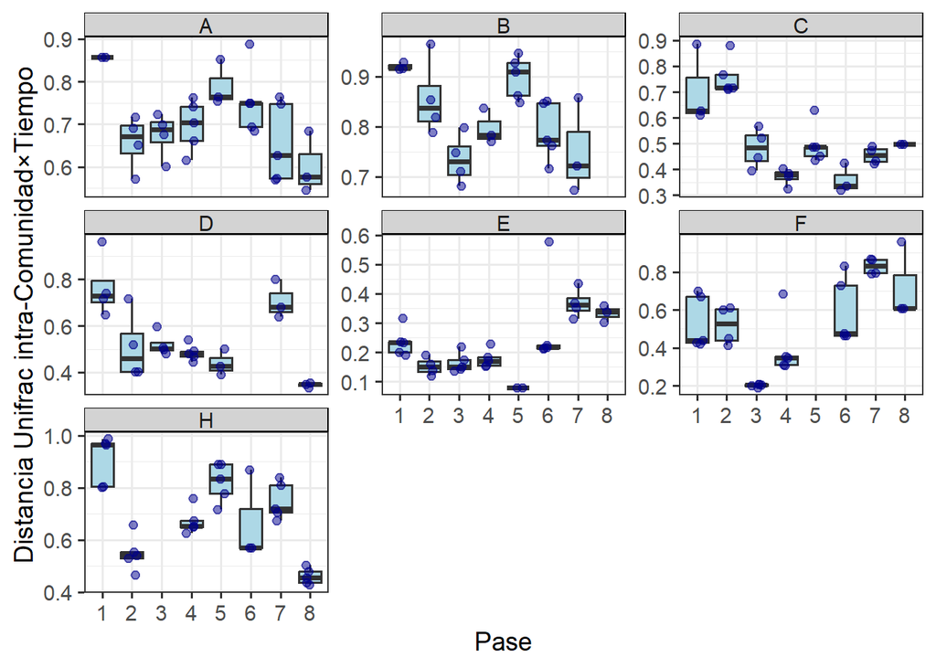

```r
bray_mat <- as.matrix(bray)


intra_bray <- sapply(seq_len(nrow(bray_mat)), function(i) {
  others <- which(meta$Comunidad == meta$Comunidad[i] &
                  meta$Tiempo    == meta$Tiempo[i] &
                  seq_len(nrow(bray_mat)) != i)
  if (length(others) < 1) return(NA_real_)   # n = 1 -> NA
  mean(bray_mat[i, others], na.rm = TRUE)
})

df_bray <-meta

df_bray$Tiempo <- factor(df_bray$Tiempo, levels = sort(unique(df_bray$Tiempo)))

Boxplot_bray<- ggplot(df_bray, aes(x = factor(Tiempo), y = intra_bray)) +
  geom_boxplot(outlier.shape = NA, coef = 1.5, fill = "lightblue") +
  geom_jitter(width = 0.2, alpha = 0.5, color = "darkblue") +
  facet_wrap(~Comunidad, scales = "free_y") +
  labs(x = "Pase", y = "Distancia Unifrac intra-Comunidad×Tiempo") +
  theme_bw(base_size = 14) +
  theme(
    strip.background = element_rect(fill = "lightgray", colour = "black", size = 0.5),
    strip.text = element_text(margin = margin(t = 1, r = 2, b = 1, l = 2))
  )
print(Boxplot_bray)
```

```r
ggsave("graficosBoxplot_bray.png",
       plot = Boxplot_bray,
       width = 10, height = 5, dpi = 300)
## -------------------------
## 1) Utilidades
## -------------------------
to_matrix <- function(bray_mat){
  if (inherits(bray_mat, "dist")) {
    as.matrix(bray_mat)
  } else {
    as.matrix(bray_mat)
  }
}

## Distancia media dentro de cada (Comunidad x time)
## y nº de pares usados (para ponderar)
mean_within_time <- function(Dmat, meta){
  stopifnot(nrow(Dmat) == nrow(meta))
  # índices por comunidad x tiempo
  grp <- interaction(meta$Comunidad, meta$Tiempo, drop = TRUE)
  idx_list <- split(seq_len(nrow(Dmat)), grp)

  out <- lapply(names(idx_list), function(nm){
    ix <- idx_list[[nm]]
    # Necesitamos al menos 2 réplicas para formar pares
    if (length(ix) < 2) return(NULL)
    Di <- Dmat[ix, ix, drop = FALSE]
    # media de triángulo superior
    m <- mean(Di[upper.tri(Di)])
    n_pairs <- choose(length(ix), 2)
    parts <- strsplit(nm, split="\\.")[[1]]
    data.frame(Comunidad = parts[1],
               Tiempo = as.numeric(paste(parts[-1], collapse=".")), # soporta tiempos no enteros
               mean_dist = m,
               n_pairs = n_pairs,
               stringsAsFactors = FALSE)
  })
  do.call(rbind, out)
}

## Pendiente por comunidad (WLS por nº de pares)
slope_by_Comunidad <- function(df_ct){
  split(df_ct, df_ct$Comunidad) |>
    lapply(function(dd){
      dd <- dd[order(dd$Tiempo), ]
      # si hay menos de 2 tiempos con datos, no podemos estimar pendiente
      if (nrow(dd) < 2) return(data.frame(slope = NA_real_,
                                          n_pairs_total = sum(dd$n_pairs)))
      fit <- try(suppressWarnings(
        lm(mean_dist ~ Tiempo, data = dd, weights = n_pairs)
      ), silent = TRUE)
      if (inherits(fit, "try-error")) {
        data.frame(slope = NA_real_, n_pairs_total = sum(dd$n_pairs))
      } else {
        data.frame(slope = unname(coef(fit)["Tiempo"]),
                   n_pairs_total = sum(dd$n_pairs))
      }
    }) |>
    (\(lst) {
      ans <- do.call(rbind, lst)
      ans$Comunidad <- rownames(ans)
      rownames(ans) <- NULL
      ans
    })()
}

## Estadístico global: media ponderada de pendientes por nº total de pares
global_stat <- function(tab_slope){
  w <- tab_slope$n_pairs_total
  s <- tab_slope$slope
  # Si hay NAs, ignora esas comunidades (sin datos suficientes)
  keep <- is.finite(s) & is.finite(w) & w > 0
  sum(s[keep] * w[keep]) / sum(w[keep])
}

## Pipeline para obtener estadístico observado
compute_observed <- function(Dmat, meta){
  df_ct <- mean_within_time(Dmat, meta)
  tab_slope <- slope_by_Comunidad(df_ct)
  list(df_ct = df_ct,
       tab_slope = tab_slope,
       stat_global = global_stat(tab_slope))
}

## Permutación: baraja 'time' **dentro de cada comunidad**
permute_times_within_comm <- function(meta){
  meta_perm <- meta
  meta_perm$Tiempo <- ave(meta$Tiempo, meta$Comunidad, FUN = function(t) sample(t))
  meta_perm
}

## -------------------------
## 2) Preparación de datos
## -------------------------
## Alinea meta y Dmat
Dmat <- to_matrix(bray_mat)

## Asegura que meta$Nombre alinea con filas/columnas de Dmat
## (suponemos que rownames(Dmat) son Nombres)
stopifnot(all(meta$Nombre %in% rownames(Dmat)))
## reordenamos meta y D para que coincidan
meta <- meta[match(rownames(Dmat), meta$Nombre), ]
stopifnot(all(meta$Nombre == rownames(Dmat)))

## Coerciones
meta$Comunidad <- as.factor(meta$Comunidad)
meta$Tiempo <- as.numeric(meta$Tiempo)

## -------------------------
## 3) Observado
## -------------------------
obs <- compute_observed(Dmat, meta)
obs$tab_slope        # pendientes por comunidad
```

```
##          slope n_pairs_total Comunidad
## 1 -0.004283159            49         A
## 2 -0.010182464            41         B
## 3 -0.052986314            45         C
## 4 -0.029793016            37         D
## 5  0.023146175            56         E
## 6  0.046414021            55         F
## 7 -0.026051036            63         H
```

```r
obs$stat_global      # estadístico global (esperamos negativo si hay convergencia)
```

```
## [1] -0.005509653
```

```r
## -------------------------
## 4) Permutación restringida (p-valor global)
## -------------------------
set.seed(123)
B <- 4999  # nº de permutaciones (ajusta según tiempo disponible)

null_stats <- replicate(B, {
  meta_p <- permute_times_within_comm(meta)
  compute_observed(Dmat, meta_p)$stat_global
})

## p-valor unidireccional (H1: stat_global_obs < 0)
p_global <- (1 + sum(null_stats <= obs$stat_global)) / (B + 1)

## -------------------------
## 5) Resultados
## -------------------------
cat(sprintf("Estadístico global (pendiente media ponderada): %.6f\n", obs$stat_global))
```

```
## Estadístico global (pendiente media ponderada): -0.005510
```

```r
cat(sprintf("p-valor (unil.; convergencia: pendiente < 0): %.4f\n", p_global))
```

```
## p-valor (unil.; convergencia: pendiente < 0): 0.2432
```

```r
## (Opcional) Resumen por comunidad:
print(obs$tab_slope[order(obs$tab_slope$slope), ], row.names = FALSE)
```

```
##         slope n_pairs_total Comunidad
##  -0.052986314            45         C
##  -0.029793016            37         D
##  -0.026051036            63         H
##  -0.010182464            41         B
##  -0.004283159            49         A
##   0.023146175            56         E
##   0.046414021            55         F
```

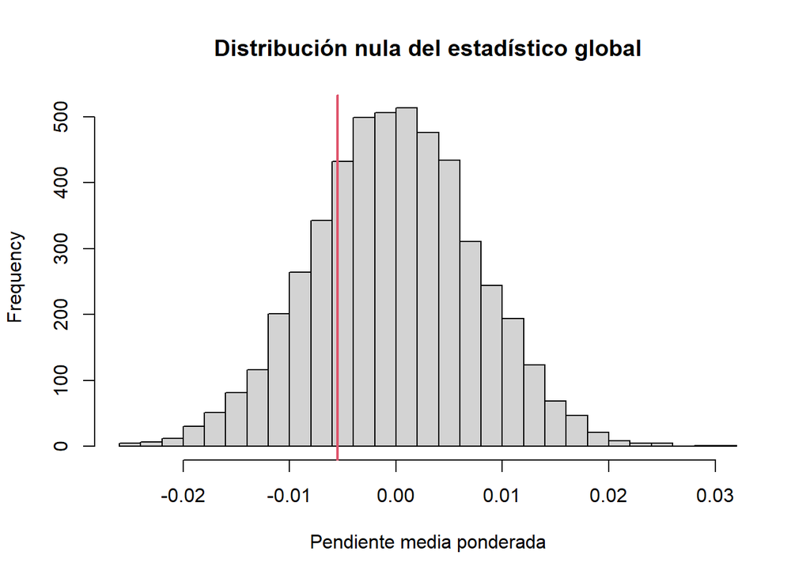

```r
## (Opcional) Visual rápido de la nula vs observado
 hist(null_stats, breaks=40, main="Distribución nula del estadístico global",
      xlab="Pendiente media ponderada")
 abline(v = obs$stat_global, col=2, lwd=2)
```

## Análisis de la evolución de la disimilitud intra-Comunidad lo largo del tiempo con distancias Unifrac

En este apartado se analiza la dinámica temporal de la composición microbiana utilizando la matriz de distancias Unifrac.A continuación se calcula la distancia media dentro de cada comunidad por cada nivel de Tiempo y se estima la tendencia temporal para cada Comunidad. Después, se ponderan las pendientes para calcular un estadístico global y se evalúa su significancia estadística mediante un test de permutación restringida.

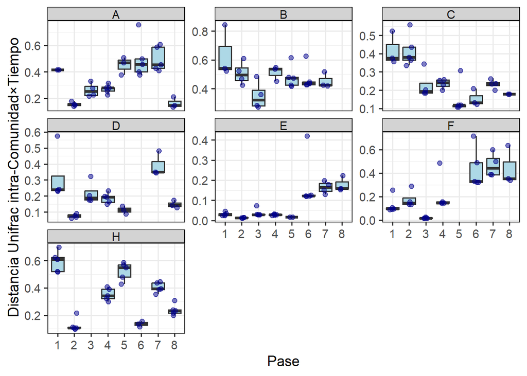

```r
Uni_mat <- as.matrix(Uni)

intra_Uni <- sapply(seq_len(nrow(Uni_mat)), function(i) {
  others <- which(meta_Uni$Comunidad == meta_Uni$Comunidad[i] &
                  meta_Uni$Tiempo    == meta_Uni$Tiempo[i] &
                  seq_len(nrow(Uni_mat)) != i)
  if (length(others) < 1) return(NA_real_)   # n = 1 -> NA
  mean(Uni_mat[i, others], na.rm = TRUE)
})

df_Uni <-meta_Uni

df_Uni$Tiempo <- factor(df_Uni$Tiempo, levels = sort(unique(df_Uni$Tiempo)))

Boxplot_Uni<- ggplot(df_Uni, aes(x = factor(Tiempo), y = intra_Uni)) +
  geom_boxplot(outlier.shape = NA, coef = 1.5, fill = "lightblue") +
  geom_jitter(width = 0.2, alpha = 0.5, color = "darkblue") +
  facet_wrap(~Comunidad, scales = "free_y") +
  labs(x = "Pase", y = "Distancia Unifrac intra-Comunidad×Tiempo") +
  theme_bw(base_size = 14) +
  theme(
    strip.background = element_rect(fill = "lightgray", colour = "black", size = 0.5),
    strip.text = element_text(margin = margin(t = 1, r = 2, b = 1, l = 2))
  )

print(Boxplot_Uni)
```

```r
ggsave("graficosBoxplot_Uni.png",
       plot = Boxplot_Uni,
       width = 10, height = 5, dpi = 300)
## -------------------------
## 1) Utilidades
## -------------------------
to_matrix <- function(D){
  if (inherits(D, "dist")) {
    as.matrix(D)
  } else {
    as.matrix(D)
  }
}

## Distancia media dentro de cada (Comunidad x time)
## y nº de pares usados (para ponderar)
mean_within_time <- function(Dmat, meta){
  stopifnot(nrow(Dmat) == nrow(meta))
  # índices por comunidad x tiempo
  grp <- interaction(meta$Comunidad, meta$Tiempo, drop = TRUE)
  idx_list <- split(seq_len(nrow(Dmat)), grp)

  out <- lapply(names(idx_list), function(nm){
    ix <- idx_list[[nm]]
    # Necesitamos al menos 2 réplicas para formar pares
    if (length(ix) < 2) return(NULL)
    Di <- Dmat[ix, ix, drop = FALSE]
    # media de triángulo superior
    m <- mean(Di[upper.tri(Di)])
    n_pairs <- choose(length(ix), 2)
    parts <- strsplit(nm, split="\\.")[[1]]
    data.frame(Comunidad = parts[1],
               Tiempo = as.numeric(paste(parts[-1], collapse=".")), # soporta tiempos no enteros
               mean_dist = m,
               n_pairs = n_pairs,
               stringsAsFactors = FALSE)
  })
  do.call(rbind, out)
}

## Pendiente por comunidad (WLS por nº de pares)
slope_by_Comunidad <- function(df_ct){
  split(df_ct, df_ct$Comunidad) |>
    lapply(function(dd){
      dd <- dd[order(dd$Tiempo), ]
      # si hay menos de 2 tiempos con datos, no podemos estimar pendiente
      if (nrow(dd) < 2) return(data.frame(slope = NA_real_,
                                          n_pairs_total = sum(dd$n_pairs)))
      fit <- try(suppressWarnings(
        lm(mean_dist ~ Tiempo, data = dd, weights = n_pairs)
      ), silent = TRUE)
      if (inherits(fit, "try-error")) {
        data.frame(slope = NA_real_, n_pairs_total = sum(dd$n_pairs))
      } else {
        data.frame(slope = unname(coef(fit)["Tiempo"]),
                   n_pairs_total = sum(dd$n_pairs))
      }
    }) |>
    (\(lst) {
      ans <- do.call(rbind, lst)
      ans$Comunidad <- rownames(ans)
      rownames(ans) <- NULL
      ans
    })()
}

## Estadístico global: media ponderada de pendientes por nº total de pares
global_stat <- function(tab_slope){
  w <- tab_slope$n_pairs_total
  s <- tab_slope$slope
  # Si hay NAs, ignora esas comunidades (sin datos suficientes)
  keep <- is.finite(s) & is.finite(w) & w > 0
  sum(s[keep] * w[keep]) / sum(w[keep])
}

## Pipeline para obtener estadístico observado
compute_observed <- function(Dmat, meta){
  df_ct <- mean_within_time(Dmat, meta)
  tab_slope <- slope_by_Comunidad(df_ct)
  list(df_ct = df_ct,
       tab_slope = tab_slope,
       stat_global = global_stat(tab_slope))
}

## Permutación: baraja 'time' **dentro de cada comunidad**
permute_times_within_comm <- function(meta){
  meta_perm <- meta
  meta_perm$Tiempo <- ave(meta$Tiempo, meta$Comunidad, FUN = function(t) sample(t))
  meta_perm
}

## -------------------------
## 2) Preparación de datos
## -------------------------
## Alinea meta y Dmat
Dmat_Uni <- to_matrix(Uni_mat)

## Asegura que meta$Nombre alinea con filas/columnas de Dmat
## (suponemos que rownames(Dmat) son Nombres)
stopifnot(all(meta_Uni$Nombre %in% rownames(Dmat_Uni)))
## reordenamos meta y D para que coincidan
meta_Uni <- meta_Uni[match(rownames(Dmat_Uni), meta_Uni$Nombre), ]
stopifnot(all(meta_Uni$Nombre == rownames(Dmat_Uni)))

## Coerciones
meta_Uni$Comunidad <- as.factor(meta_Uni$Comunidad)
meta_Uni$Tiempo <- as.numeric(meta_Uni$Tiempo)

## -------------------------
## 3) Observado
## -------------------------
obs <- compute_observed(Dmat_Uni, meta_Uni)
obs$tab_slope        # pendientes por comunidad
```

```
##           slope n_pairs_total Comunidad
## 1  0.0434903416            49         A
## 2 -0.0095212982            41         B
## 3 -0.0416183912            45         C
## 4  0.0004423098            37         D
## 5  0.0275140629            56         E
## 6  0.0632893329            55         F
## 7 -0.0150434850            63         H
```

```r
obs$stat_global      # estadístico global (esperamos negativo si hay convergencia)
```

```
## [1] 0.01143975
```

```r
## -------------------------
## 4) Permutación restringida (p-valor global)
## -------------------------
set.seed(123)
B <- 4999  # nº de permutaciones (ajusta según tiempo disponible)

null_stats <- replicate(B, {
  meta_p <- permute_times_within_comm(meta_Uni)
  compute_observed(Dmat_Uni, meta_p)$stat_global
})

## p-valor unidireccional (H1: stat_global_obs < 0)
p_global <- (1 + sum(null_stats <= obs$stat_global)) / (B + 1)

## -------------------------
## 5) Resultados
## -------------------------
cat(sprintf("Estadístico global (pendiente media ponderada): %.6f\n", obs$stat_global))
```

```
## Estadístico global (pendiente media ponderada): 0.011440
```

```r
cat(sprintf("p-valor (unil.; convergencia: pendiente < 0): %.4f\n", p_global))
```

```
## p-valor (unil.; convergencia: pendiente < 0): 0.9336
```

```r
## (Opcional) Resumen por comunidad:
print(obs$tab_slope[order(obs$tab_slope$slope), ], row.names = FALSE)
```

```
##          slope n_pairs_total Comunidad
##  -0.0416183912            45         C
##  -0.0150434850            63         H
##  -0.0095212982            41         B
##   0.0004423098            37         D
##   0.0275140629            56         E
##   0.0434903416            49         A
##   0.0632893329            55         F
```

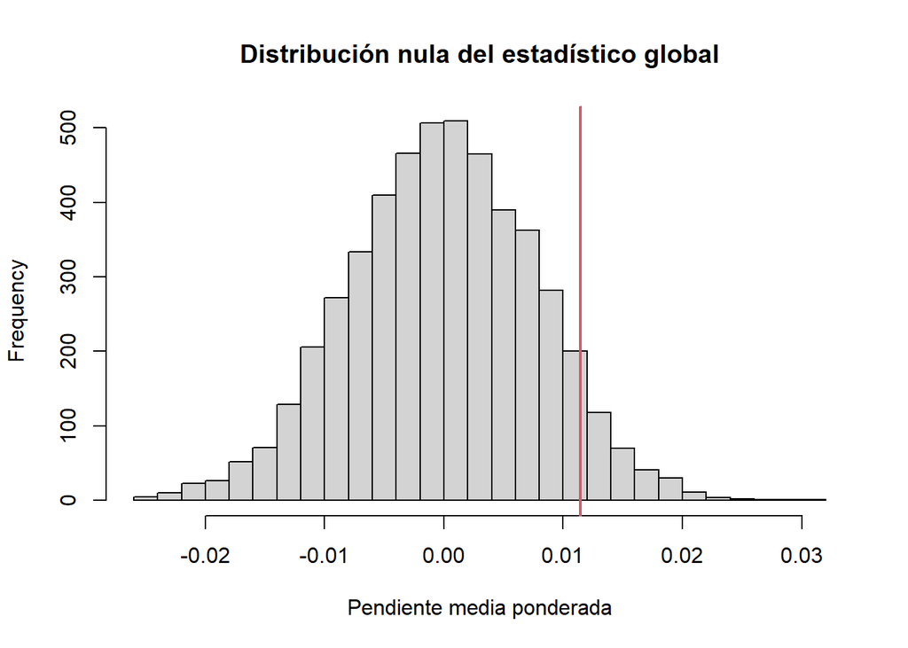

```r
## (Opcional) Visual rápido de la nula vs observado
 hist(null_stats, breaks=40, main="Distribución nula del estadístico global",
      xlab="Pendiente media ponderada")
 abline(v = obs$stat_global, col=2, lwd=2)
```